# Heart Disease Prediction

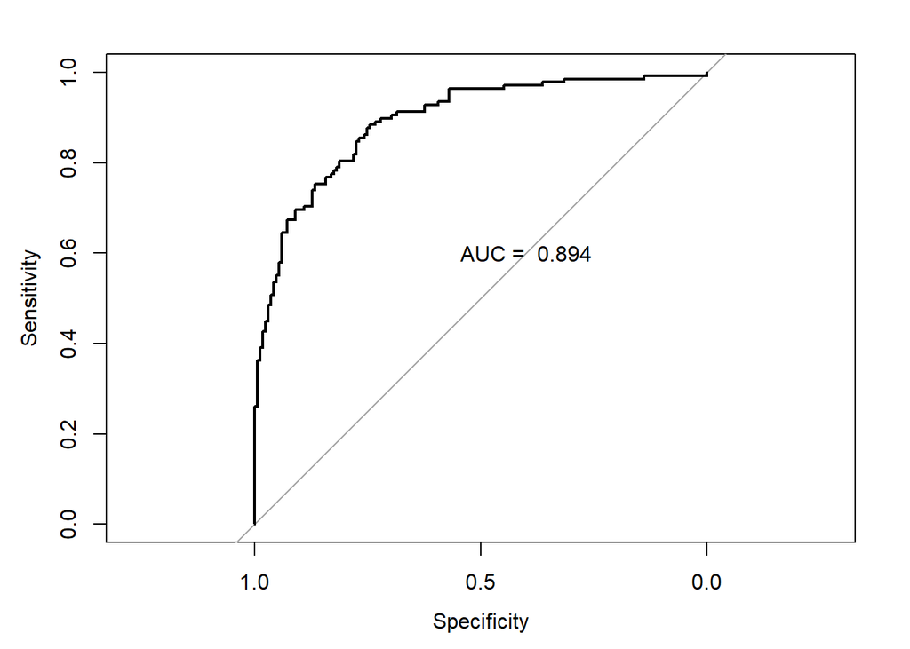

```r
#plot the ROC curve
testroc3 = roc(predictor = as.data.frame(rf_random$finalModel$votes)$Yes, response = rf_random$finalModel$y, levels = rev(levels(rf_random$finalModel$y)))
plot(testroc3, type = "S")
text(x = .40, y = .6,paste("AUC = ", round(testroc3$auc, 3)))
```

```r
#Variable Importance

varImp(rf_random$finalModel)
```

```
##             Overall
## thal1     1.1028545
## thal2    13.5124917
## thal3    11.5176656
## ca1       4.9097388
## ca2       3.6682837
## ca3       3.0328282
## ca4       0.3008541
## cp1       2.4752410
## cp2       5.2962702
## cp3       2.7291673
## sex1      4.0091806
## trestbps  9.0025224
## exang1    8.5830256
## oldpeak  14.9836688
## slope1    4.8923133
## slope2    5.6358157
```

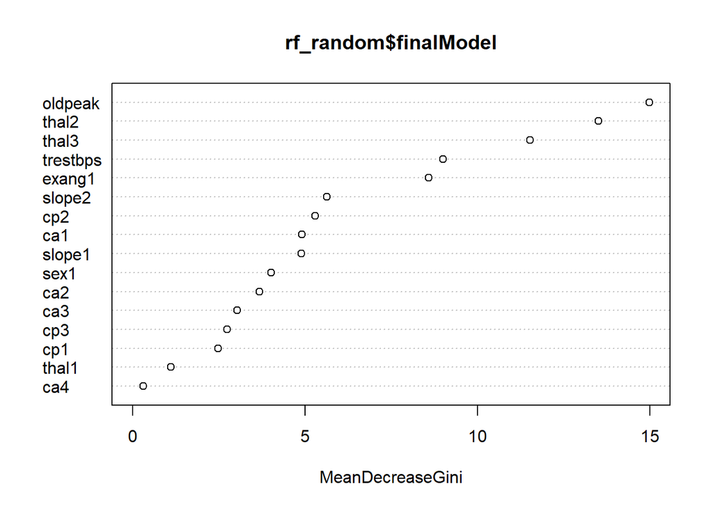

```r
varImpPlot(rf_random$finalModel)
```

# More complex model

[output not shown]

[output cut: 3452 more lines]

```
## <none>                       181.45 211.45
## - trestbps               1   185.87 213.87
## - ca3                    1   185.92 213.92
## - thalach                1   186.24 214.24
## - thal1                  1   187.24 215.24
## - cp1                    1   187.27 215.27
## - `log(oldpeak + 0.01)`  1   187.95 215.95
## - sex1                   1   192.94 220.94
## - slope1                 1   194.61 222.61
## - thal2                  1   195.27 223.27
## - cp3                    1   195.28 223.28
## - oldpeak                1   195.75 223.75
## - ca2                    1   203.26 231.26
## - cp2                    1   203.45 231.45
## - ca1                    1   204.59 232.59
```

# Andy’s Complex Model

[output not shown]

[output cut: 1891 more lines]

```
##
##            Df Deviance    AIC
## <none>          187.48 213.48
## - cp1       1   191.28 215.28
## - exang1    1   191.53 215.53
## - trestbps  1   191.63 215.63
## - ca3       1   195.74 219.74
## - oldpeak   1   196.12 220.12
## - sex1      1   198.38 222.38
## - slope1    1   199.72 223.72
## - thal3     1   200.56 224.56
## - cp3       1   202.57 226.57
## - ca2       1   207.81 231.81
## - cp2       1   208.62 232.62
## - ca1       1   213.05 237.05
```

```
##   parameter       ROC      Sens      Spec      ROCSD     SensSD     SpecSD
## 1      none 0.9069166 0.8098901 0.8790441 0.05820122 0.08995639 0.04869531
```

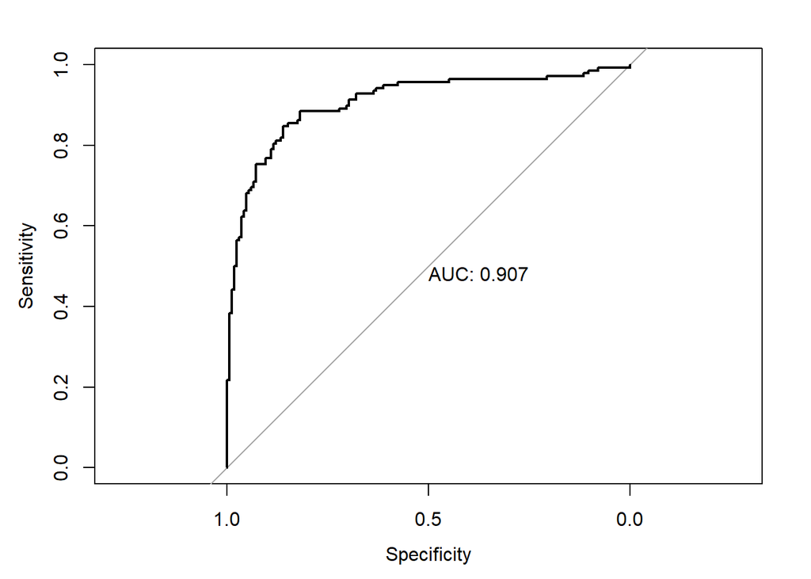

# LDA

Let’s run an LDA model on the continuous variables and see how the model performs:

```r
# Assumptions are Multivariate Normally Distributed Residual and Equal Covariance Matricies
## Histogram of logged oldpeak predictor improves normality

#Run the LDA
heart_lda = LinearDA(Data = as.data.frame(heartcont), selectedCols = c("age","trestbps", "chol", "thalach", "oldpeak", "target"), classCol = 6, cvType = "folds", nTrainFolds = 10, extendedResults = TRUE)
```

[output not shown]

```r
#output the results
heart_lda$ConfusionMatrixResults
```

```
## Confusion Matrix and Statistics
##
##           Reference
## Prediction   0   1
##          0  64  66
##          1  43 127
##
##                Accuracy : 0.6367
##                  95% CI : (0.5794, 0.6912)
##     No Information Rate : 0.6433
##     P-Value [Acc > NIR] : 0.6204
##
##                   Kappa : 0.2445
##
##  Mcnemar's Test P-Value : 0.0351
##
##             Sensitivity : 0.5981
##             Specificity : 0.6580
##          Pos Pred Value : 0.4923
##          Neg Pred Value : 0.7471
##              Prevalence : 0.3567
##          Detection Rate : 0.2133
##    Detection Prevalence : 0.4333
##       Balanced Accuracy : 0.6281
##
##        'Positive' Class : 0
##
```

```r
# Box's M-Test for homogeneity of covariance matricies (test requires multivariate normal data)
## Did not work for simply logging oldpeak, since any obserations with 0 resulted in undefined value from the transformation (no p-value provided)
# res <- boxM(cbind(age,trestbps,chol,thalach,log(oldpeak)) ~ target, data = heart)

#You can run this if you just add a small value to oldpeak, but the result is still non-normal.
boxM(cbind(age,trestbps,chol,thalach,log(oldpeak+0.01)) ~ target, data = heart)
```

```
##
##  Box's M-test for Homogeneity of Covariance Matrices
##
## data:  Y
## Chi-Sq (approx.) = 42.596, df = 15, p-value = 0.0001819
```

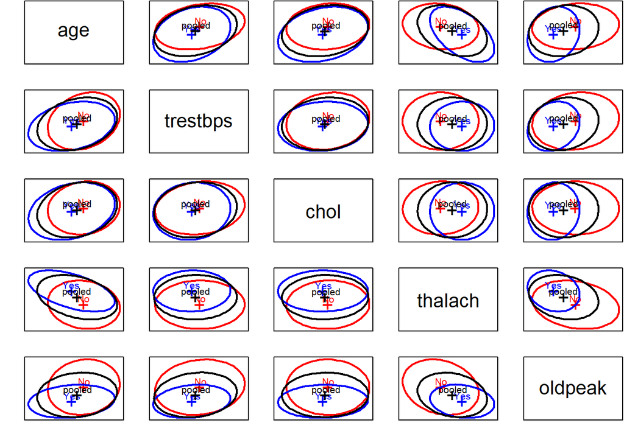

```r
# Alternative check to covariance assumption through visualization of Covariance Ellipses
covEllipses(heart[,c("age","trestbps","chol","thalach","oldpeak")], heart$target,
            fill=c(rep(FALSE,3), TRUE), variables=1:5, fill.alpha=.1)
```

```r
# Build QDA model due to violation of homogeneous covariance matricies
heart.qda <- qda(target ~ age + trestbps + chol + thalach + oldpeak, CV = TRUE, data = heart)
table(heart$target, heart.qda$class, dnn = c('Actual Group','Predicted Group'))
```

```
##             Predicted Group
## Actual Group  No Yes
##          No   85  53
##          Yes  29 136
```

```r
# Performance Metrics
TN <- 85
TP <- 136
FN <- 29
FP <- 53
Total <- TN + TP + FN + FP
## Accuracy
acc <- (TP+TN)/Total
acc
```

```
## [1] 0.7293729
```

```r
## Sensitivity
sen <- TP/(TP+FN)
sen
```

```
## [1] 0.8242424
```

```r
## Specificity
spe <- TN/(TN+FP)
spe
```

```
## [1] 0.615942
```

The LDA/QDA models will not perform as well logistic regression model. QDA should be used in favor of LDA model since assumptions of equal covariance matrix is violated as shown in the Covariance Ellipses Matrix. However, the assumption of multivariate normally distributed data is also violated with oldpeak predictor, so logistic regression model should be used in favor of QDA for classification of heart disease.

Just to try another selection algorithm, used “LogitBoost” from the Caret library. It doesn’t consistently outperform the simpler stepwise selection or “all-in” methods. We haven’t learned the interpretation for this model.

```
## $Stump
##       feature threshhold sign
##  [1,]      21        0.0   -1
##  [2,]      12        0.0    1
##  [3,]      13        0.7    1
##  [4,]       4        0.0   -1
##  [5,]      16        0.0    1
##  [6,]       5        0.0   -1
##  [7,]      17        0.0    1
##  [8,]       7      228.0    1
##  [9,]       2        0.0    1
## [10,]       7      197.0   -1
## [11,]       1       56.0    1
## [12,]      20        0.0   -1
## [13,]       1       50.0   -1
## [14,]      11      143.0   -1
## [15,]       6      122.0    1
## [16,]       9        0.0   -1
## [17,]       6      126.0   -1
## [18,]       1       63.0   -1
## [19,]       6      150.0    1
## [20,]       9        0.0    1
## [21,]       1       45.0    1
##
## $lablist
## [1] No  Yes
## Levels: No Yes
##
## $xNames
##  [1] "age"      "sex1"     "cp1"      "cp2"      "cp3"      "trestbps"
##  [7] "chol"     "fbs1"     "restecg1" "restecg2" "thalach"  "exang1"
## [13] "oldpeak"  "slope1"   "slope2"   "ca1"      "ca2"      "ca3"
## [19] "ca4"      "thal1"    "thal2"    "thal3"
##
## $problemType
## [1] "Classification"
##
## $tuneValue
##   nIter
## 2    21
##
## $obsLevels
## [1] "No"  "Yes"
## attr(,"ordered")
## [1] FALSE
##
## $param
## $param$family
## [1] "binomial"
##
##
## attr(,"class")
## [1] "LogitBoost"
```

```
##   nIter       ROC      Sens      Spec      ROCSD     SensSD     SpecSD
## 1    11 0.8616496 0.7890110 0.8238971 0.07038709 0.08377795 0.06922555
## 2    21 0.8727042 0.7664835 0.8367647 0.05861390 0.12951321 0.07808979
## 3    31 0.8687096 0.7538462 0.8308824 0.05423161 0.08713792 0.10644143
```

Elasticnet:

```
## 23 x 1 Matrix of class "dgeMatrix"
##                     1
## (Intercept) 2.1435972
## age         1.0000000
## sex1        0.4640680
## cp1         1.6760403
## cp2         2.6535806
## cp3         2.6978249
## trestbps    0.9915173
## chol        0.9986095
## fbs1        1.0521352
## restecg1    1.3336606
## restecg2    0.9061004
## thalach     1.0119185
## exang1      0.5238660
## oldpeak     0.7600913
## slope1      0.6675914
## slope2      1.4352732
## ca1         0.3443263
## ca2         0.2293225
## ca3         0.3376745
## ca4         1.4505159
## thal1       1.0495681
## thal2       1.7986111
## thal3       0.5151357
```

# Appendix A:

Variable names and meanings pulled from the source website: https://archive.ics.uci.edu/ml/datasets/Heart+Disease

*Chest Pain Type (cp)* [SOURCE: https://www.aafp.org/afp/2005/1115/p2012.html]

Angina is chest pain that results from reduced blood flow to the heart muscle.

Typical angina (definite chest pain) meets three of the following characteristics

1. Substernal chest discomfort of characteristic quality and duration
2. Provoked by exertion or emotional stress
3. Relieved by rest and/or nitroglycerine

Atypical angina (probable chest pain) meets two of the characteristics

Non-anginal pain meets one characteristic

Asymptomatic means no chest pain

*Resting Blood Pressure (trestbps)*

High blood pressure is a common condition and major risk factor for heart disease. Uncontrolled hypertension can lead to heart attack and stroke

*Serum Cholesterol (chol)*

[SOURCE: https://www.medicalnewstoday.com/articles/321519.php]

Serum cholesterol measures the amount of triglycerides, low-density lipoprotein (LDL/bad cholesterol), and high density lipoprotein (HDL/good cholesterol). High serum cholesterol levels are associated with higher risk for coronary artery disease and heart attack

*Normal Ranges for cholesterol levels*

<= 19 years old - serum chol [<= 170 mg/dL] - HDL [>= 45 mg/dL] - LDL [< 100 mg/dL] - Triglycerides [< 150 mg/dL] >= 20 years old female - serum chol [125-200 mg/dL] - HDL [>= 50 mg/dL] - LDL [< 100 mg/dL] - Triglycerides [< 150 mg/dL] >= 20 years old male - serum chol [125-200 mg/dL] - HDL [>= 40 mg/dL] - LDL [< 100 mg/dL] - Triglycerides [< 150 mg/dL]

*Fasing Blood Sugar (fbs)*

[SOURCE: https://www.mayoclinic.org/diseases-conditions/diabetes/diagnosis-treatment/drc-20371451]

Ranges:

1. fbs < 100 mg/dL is normal
2. fbs 100-125 mg/dL is prediabetes
3. fbs >= 126 mg/dL on two separate tests diagnoses diabetes

A fasting blood sugar level of more than 125 mg/dL is current threshold for diabetes. Higher fasting blood sugars are associatied with higher risk for heart disease.

*Resting Electrocardiographic Results (restecg)*

[SOURCE: https://www.mayoclinic.org/diseases-conditions/left-ventricular-hypertrophy/symptoms-causes/syc-20374314]

ST-T Wave Abnormality (1) are associated with increased cardiac deaths and are highly suggestive of coronary artery disease when associcated with cardiac signs and symptoms. T wave inversions and/or ST elevation or depression of > 0.05 mV.

Left Ventricular Hypertrophy (2) is enlargement/thickening (hypertrophy) of the walls of your heart’s main pumping chamber (left ventricle) and causes it to work harder.

- Defined using Estes’ criteria
  - As the workload increases, the muscle tissue in the chamber wall thickens. The enlarged heart muscle loses elasticity and may eventually fail to pump with as much force as needed.
  - Left ventricular hypertrophy is more common in people who have uncontrolled high blood pressure and puts you at higher risk of a heart attack and stroke.

*Maximum Heart Rate Achieved (thalach)*

[SOURCE: https://www.hopkinsmedicine.org/health/wellness-and-prevention/understanding-your-target-heart-rate]

The maximum heart rate is based on your age, as subtracted from 220.

- For a 50-year-old, maximum heart rate is 220 minus 50, or 170 beats per minute.
  - Target heart rate that a 50-year-old would want to aim for during exercise is 85 to 145 beats per minute (50%-85% exertion level).
  - Maximum heart rates below these averages may indicate weakening of heart muscle

*Exercise Induced Angina*

Chest pain that is triggered by physical exertion. When you climb stairs, exercise or walk, your heart demands more blood, but it’s harder for the muscle to get enough blood when your arteries are narrowed.

*ST Depression Induced (oldpeak)*

[SOURCE: https://www.ahajournals.org/doi/pdf/10.1161/01.CIR.80.1.87]

- Units are in mV

ST segment depression in PQRST wave (ECG) may be assoicated with coronary artery disease with larger depressions indicative of abnormality. Exercise stress test requires an ST depression of at least 2 mm to significantly indicate reversible ischaemia [WIKI]

*Slope of Peak Exercise ST Segment (slope)*

[SOURCE: https://ecgwaves.com/ecg-topic/exercise-stress-test-ecg-symptoms-blood-pressure-heart-rate-performance/]

- Steep slopes indicate a less likely chance of ischemia
- Horizontal/Flat slopes indicate a more likely chance of ischemia

*Number of Major Vessels Colored by Flouroscopy (ca)*

*Severity of Defect (thal)*

*target*

Diagnosis of heart disease (angiographic disease status)

Value 0: < 50% diameter narrowing Value 1: > 50% diameter narrowing (in any major vessel: attributes 59 through 68 are vessels)

# Appendix B: Additional Exploratory Analysis Performed

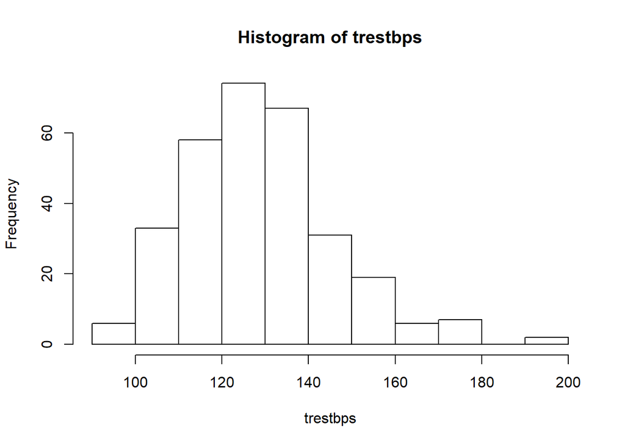

```r
#Histogram of trestbps
hist(trestbps)
```

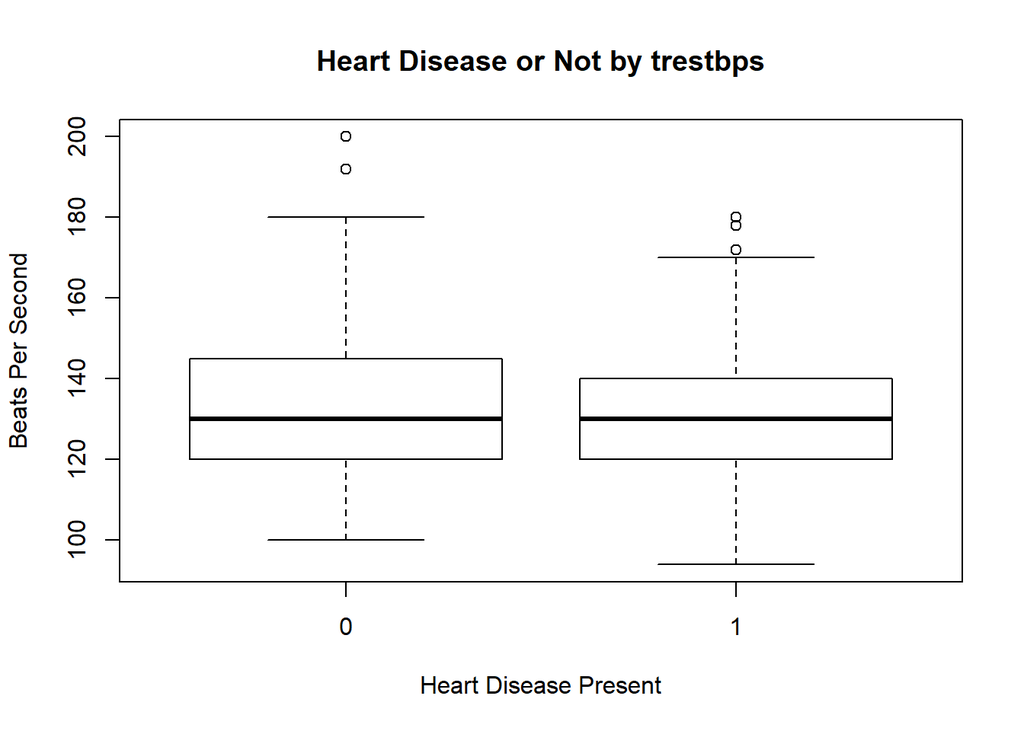

```r
#Boxplot of trestbps by response
boxplot(trestbps~target, main = "Heart Disease or Not by trestbps", ylab = "Beats Per Second", xlab = "Heart Disease Present")
```

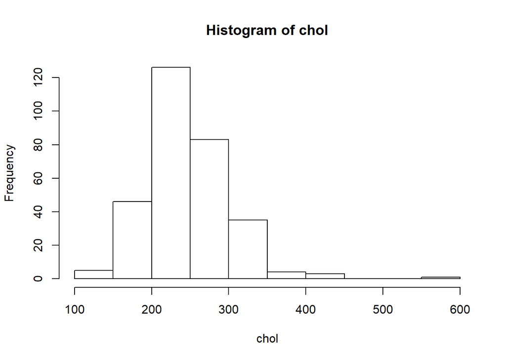

```r
#Histogram of chol
hist(chol)
```

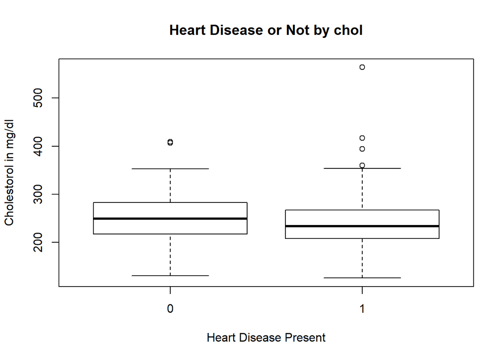

```r
#Boxplot of chol vs response
boxplot(chol~target, main = "Heart Disease or Not by chol", xlab = "Heart Disease Present", ylab = "Cholestorol in mg/dl")
```

```r
#Values of fbs in the data set
kable(table(fbs))
```

| fbs | Freq |
| --- | --- |
| 0 | 258 |
| 1 | 45 |

```r
#Values of restecg in the data set
kable(table(restecg))
```

| restecg | Freq |
| --- | --- |
| 0 | 147 |
| 1 | 152 |
| 2 | 4 |

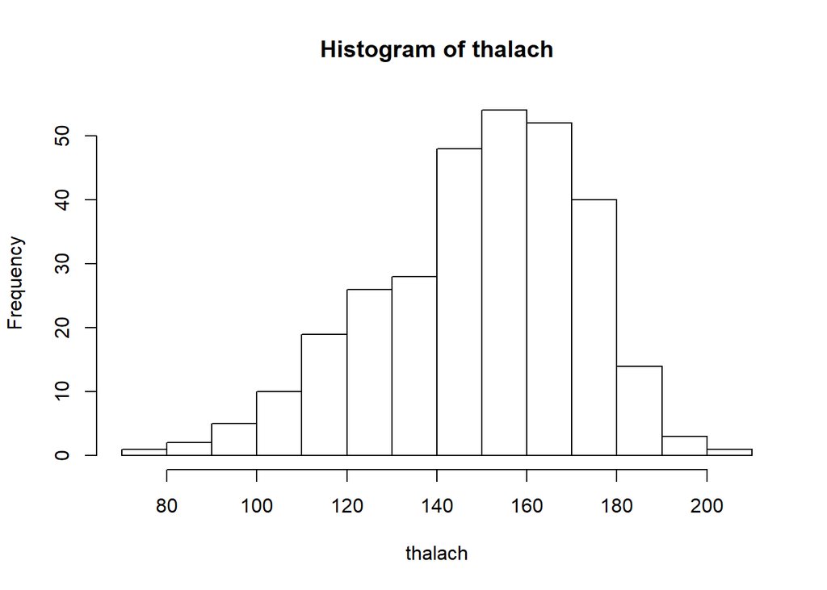

```r
#Histogram of thalach
hist(thalach)
```

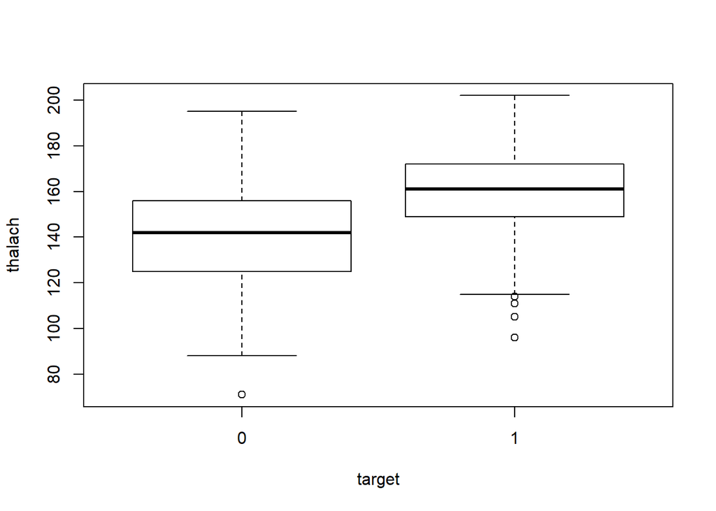

```r
#Boxplot of thalach against response
boxplot(thalach~target)
```

```r
#Some good differentiation here

#Values of exang in the data
kable(table(exang))
```

| exang | Freq |
| --- | --- |
| 0 | 204 |
| 1 | 99 |

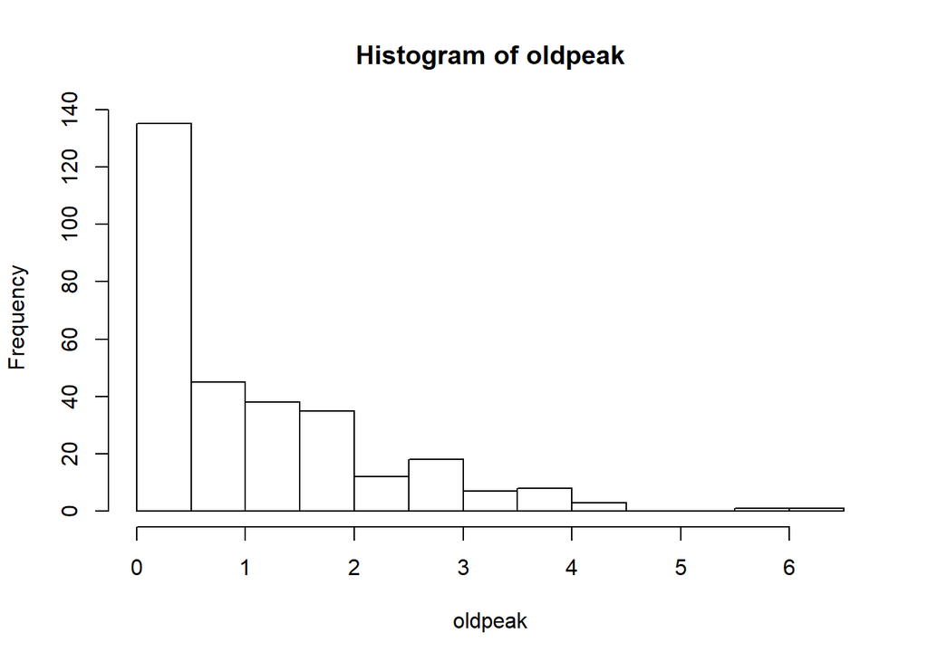

```r
#Histogram of oldpeak
hist(oldpeak)
```

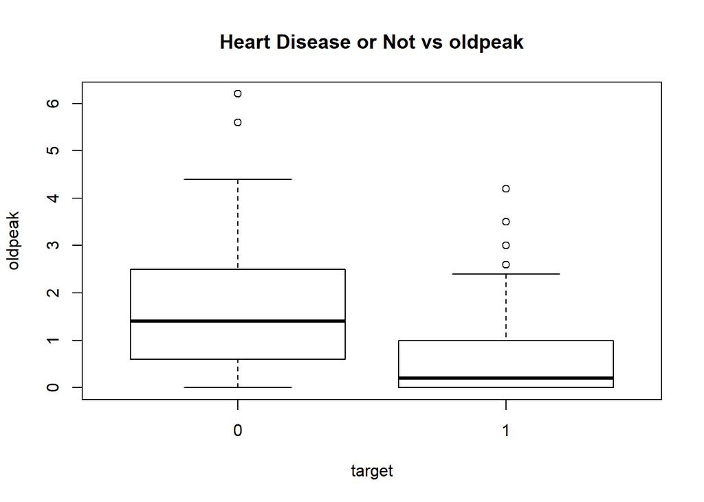

```r
#Some strong right skew here that may need to be addressed if we use this as a continuous variable. And I think we should initially.

#Boxplot of oldpeak
boxplot(oldpeak~target, main = "Heart Disease or Not vs oldpeak")
```

```r
#Values of slope occuring
kable(table(slope))
```

| slope | Freq |
| --- | --- |
| 0 | 21 |
| 1 | 140 |
| 2 | 142 |

```r
#Values of ca occuring
kable(table(ca))
```

| ca | Freq |
| --- | --- |
| 0 | 175 |
| 1 | 65 |
| 2 | 38 |
| 3 | 20 |
| 4 | 5 |

```r
#Values of thal occuring
kable(table(thal))
```

| thal | Freq |
| --- | --- |
| 0 | 2 |
| 1 | 18 |
| 2 | 166 |
| 3 | 117 |

```r
#Distribution of the target response seems roughly 50-50
kable(table(target))
```

| target | Freq |
| --- | --- |
| 0 | 138 |
| 1 | 165 |